# Bayesian GLM Part7

Author

Murray Logan

Published

09/09/2025

# 1 Preparations

Load the necessary libraries

```r
library(tidyverse) # for data wrangling etc
library(rstanarm) # for fitting models in STAN
library(cmdstanr) # for cmdstan
library(brms) # for fitting models in STAN
library(standist) # for exploring distributions
library(coda) # for diagnostics
library(bayesplot) # for diagnostics
library(ggmcmc) # for MCMC diagnostics
library(DHARMa) # for residual diagnostics
library(rstan) # for interfacing with STAN
library(emmeans) # for marginal means etc
library(broom) # for tidying outputs
library(tidybayes) # for more tidying outputs
library(HDInterval) # for HPD intervals
library(ggeffects) # for partial plots
library(broom.mixed) # for summarising models
library(posterior) # for posterior draws
library(ggeffects) # for partial effects plots
library(patchwork) # for multi-panel figures
library(bayestestR) # for ROPE
library(see) # for some plots
library(easystats) # framework for stats, modelling and visualisation
library(geoR) # framework for stats, modelling and visualisation
library(modelsummary) # for data and model summaries
theme_set(theme_grey()) # put the default ggplot theme back
source("helperFunctions.R")
```

# 2 Scenario

Freitas et al. (2016) investigated the effect of sea temperature on habitat selection and habitat use of acoustically tagged Atlantic cod (*Gadus morhua*) a the Norwegian Skagerrak coast. More specifically, they explored the relationship between sea temperature and how deep individually tagged Atlantic cod dove during the day and night. These data were collected between late June and early December 2013, although the duration of the data varies across the different individual cod.

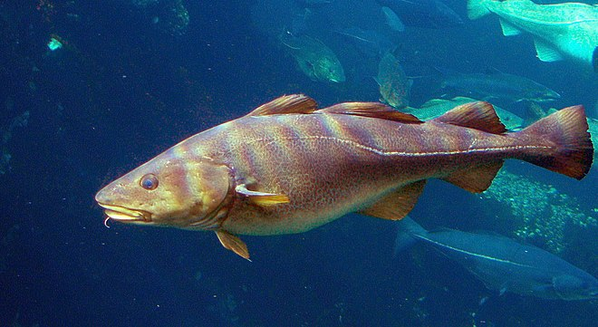

**Figure** 1: Atlantic cod

The data are in the file **freitas.csv** in the **data** folder.

**Table** 1: Format of the freitas.csv data file

| FISH | DATE | DEPTH_MEAN_DAY | DEPTH_MEAN_NIGHT | TEMPERATURE |
| --- | --- | --- | --- | --- |
| Cod_6755 | 2013-06-28 | 19.64416667 | 19.59565217 | 18.00541667 |
| Cod_6755 | 2013-06-29 | 19.98275862 | 19.72678571 | 17.75595833 |
| Cod_6755 | 2013-06-30 | 19.94709302 | 20.040625 | 17.181125 |
| Cod_6755 | 2013-07-01 | 19.96827957 | 19.94153846 | 17.49952174 |
| Cod_6755 | 2013-07-02 | 17.74377907 | 19.93 | 17.601375 |
| Cod_6755 | 2013-07-03 | 14.47237037 | 19.12307692 | 17.6055 |
| ... | ... |  |  |  |

**Table** 2: Description of the variables in the freitas data file

| **FISH**: | Individual Atlantic code fish ID - Random variable |
| --- | --- |
| **DATE**: | Date of observation - Covariate variable |
| **DEPTH_MEAN_DAY**: | Mean dive depth that day - Response variable |
| **DEPTH_MEAN_NIGHT**: | Mean dive depth that night - Response variable |
| **TEMPERATUREd**: | Sea surface temperature - Predictor variable |

# 3 Read in the data

```r
freitas <- read_csv("../data/freitas.csv", trim_ws = TRUE)
```

**glimpse**

```r
glimpse(freitas)
```

```
Rows: 5,083
Columns: 5
$ FISH             <chr> "Cod_6755", "Cod_6755", "Cod_6755", "Cod_6755", "Cod_…
$ DATE             <date> 2013-06-28, 2013-06-29, 2013-06-30, 2013-07-01, 2013…
$ DEPTH_MEAN_DAY   <dbl> 19.64417, 19.98276, 19.94709, 19.96828, 17.74378, 14.…
$ DEPTH_MEAN_NIGHT <dbl> 19.59565, 19.72679, 20.04062, 19.94154, 19.93000, 19.…
$ TEMPERATURE      <dbl> 18.00542, 17.75596, 17.18113, 17.49952, 17.60138, 17.…
```

**head**

```r
## Explore the first 6 rows of the data
head(freitas)
```

```
# A tibble: 6 × 5
  FISH     DATE       DEPTH_MEAN_DAY DEPTH_MEAN_NIGHT TEMPERATURE
  <chr>    <date>              <dbl>            <dbl>       <dbl>
1 Cod_6755 2013-06-28           19.6             19.6        18.0
2 Cod_6755 2013-06-29           20.0             19.7        17.8
3 Cod_6755 2013-06-30           19.9             20.0        17.2
4 Cod_6755 2013-07-01           20.0             19.9        17.5
5 Cod_6755 2013-07-02           17.7             19.9        17.6
6 Cod_6755 2013-07-03           14.5             19.1        17.6
```

**str**

```r
str(freitas)
```

```
spc_tbl_ [5,083 × 5] (S3: spec_tbl_df/tbl_df/tbl/data.frame)
 $ FISH            : chr [1:5083] "Cod_6755" "Cod_6755" "Cod_6755" "Cod_6755" ...
 $ DATE            : Date[1:5083], format: "2013-06-28" "2013-06-29" ...
 $ DEPTH_MEAN_DAY  : num [1:5083] 19.6 20 19.9 20 17.7 ...
 $ DEPTH_MEAN_NIGHT: num [1:5083] 19.6 19.7 20 19.9 19.9 ...
 $ TEMPERATURE     : num [1:5083] 18 17.8 17.2 17.5 17.6 ...
 - attr(*, "spec")=
  .. cols(
  ..   FISH = col_character(),
  ..   DATE = col_date(format = ""),
  ..   DEPTH_MEAN_DAY = col_double(),
  ..   DEPTH_MEAN_NIGHT = col_double(),
  ..   TEMPERATURE = col_double()
  .. )
 - attr(*, "problems")=<externalptr>
```

**Easystats (datawizard)**

```r
freitas |> datawizard::data_codebook()
```

```
freitas (5083 rows and 5 variables, 5 shown)

ID | Name             | Type      | Missings |        Values |          N
---+------------------+-----------+----------+---------------+-----------
1  | FISH             | character | 0 (0.0%) |      Cod_6755 | 101 (2.0%)
   |                  |           |          |      Cod_6761 | 104 (2.0%)
   |                  |           |          |      Cod_6765 | 105 (2.1%)
   |                  |           |          |      Cod_6766 |  93 (1.8%)
   |                  |           |          |      Cod_6773 | 107 (2.1%)
   |                  |           |          |      Cod_6776 |   6 (0.1%)
   |                  |           |          |      Cod_6778 |  53 (1.0%)
   |                  |           |          |      Cod_6779 | 156 (3.1%)
   |                  |           |          |      Cod_6780 | 107 (2.1%)
   |                  |           |          |      Cod_6783 | 107 (2.1%)
   |                  |           |          |         (...) |
---+------------------+-----------+----------+---------------+-----------
2  | DATE             | date      | 0 (0.0%) |    2013-06-28 |  44 (0.9%)
   |                  |           |          |    2013-06-29 |  45 (0.9%)
   |                  |           |          |    2013-06-30 |  44 (0.9%)
   |                  |           |          |    2013-07-01 |  44 (0.9%)
   |                  |           |          |    2013-07-02 |  45 (0.9%)
   |                  |           |          |    2013-07-03 |  45 (0.9%)
   |                  |           |          |    2013-07-04 |  42 (0.8%)
   |                  |           |          |    2013-07-05 |  42 (0.8%)
   |                  |           |          |    2013-07-06 |  42 (0.8%)
   |                  |           |          |    2013-07-07 |  42 (0.8%)
   |                  |           |          |         (...) |
---+------------------+-----------+----------+---------------+-----------
3  | DEPTH_MEAN_DAY   | numeric   | 0 (0.0%) | [1.68, 41.41] |       5083
---+------------------+-----------+----------+---------------+-----------
4  | DEPTH_MEAN_NIGHT | numeric   | 0 (0.0%) | [0.05, 37.85] |       5083
---+------------------+-----------+----------+---------------+-----------
5  | TEMPERATURE      | numeric   | 0 (0.0%) |  [6.72, 21.1] |       5083
-------------------------------------------------------------------------
```

**Skim (modelsummary)**

Unique

Missing Pct.

Mean

SD

Min

Median

Max

Histogram

DEPTH_MEAN_DAY

5053

0

17.7

6.4

1.7

19.5

41.4

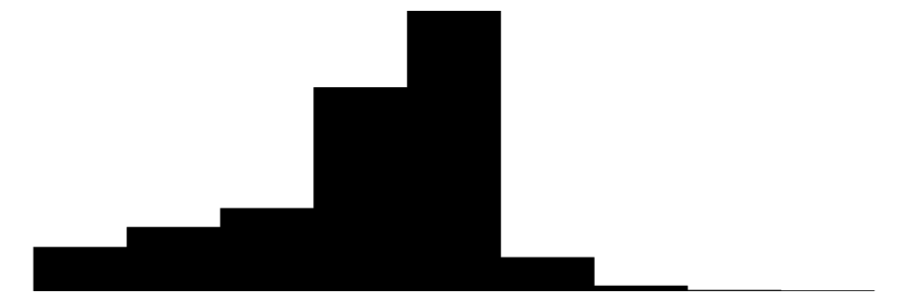

DEPTH_MEAN_NIGHT

5053

0

15.3

7.3

0.0

16.7

37.9

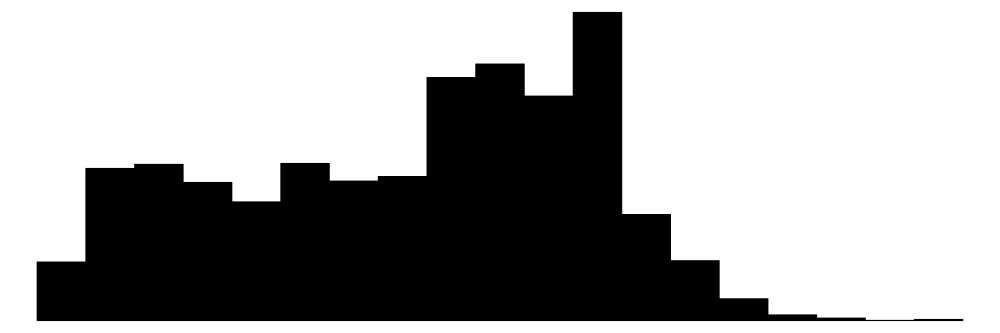

TEMPERATURE

159

0

16.5

3.5

6.7

17.8

21.1

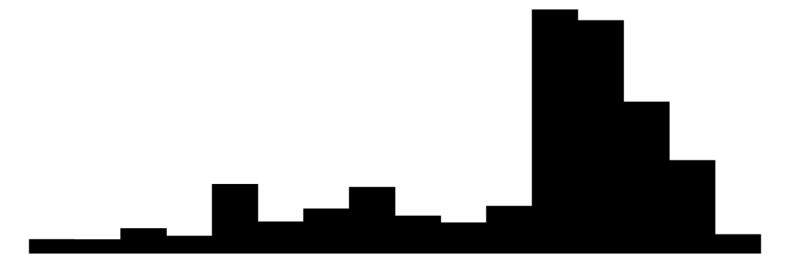

FISH

N

%

Cod_6755

101

2.0

Cod_6761

104

2.0

Cod_6765

105

2.1

Cod_6766

93

1.8

Cod_6773

107

2.1

Cod_6776

6

0.1

Cod_6778

53

1.0

Cod_6779

156

3.1

Cod_6780

107

2.1

Cod_6783

107

2.1

Cod_6784

62

1.2

Cod_6785

111

2.2

Cod_6787

92

1.8

Cod_6791

110

2.2

Cod_6793

111

2.2

Cod_6795

111

2.2

Cod_7266

109

2.1

Cod_7267

112

2.2

Cod_7270

114

2.2

Cod_7272

56

1.1

Cod_7274

26

0.5

Cod_7279

102

2.0

Cod_7280

159

3.1

Cod_7282

57

1.1

Cod_7283

112

2.2

Cod_7285

59

1.2

Cod_7286

46

0.9

Cod_8981

107

2.1

Cod_8982

54

1.1

Cod_8984

158

3.1

Cod_8985

156

3.1

Cod_8986

159

3.1

Cod_8987

48

0.9

Cod_8988

159

3.1

Cod_8999

27

0.5

Cod_9000

159

3.1

Cod_9002

65

1.3

Cod_9003

150

3.0

Cod_9004

159

3.1

Cod_9005

159

3.1

Cod_9031

159

3.1

Cod_9032

151

3.0

Cod_9034

159

3.1

Cod_9035

83

1.6

Cod_9043

159

3.1

Cod_9044

159

3.1

Cod_9045

102

2.0

Cod_9046

63

1.2

```r
freitas |> modelsummary::datasummary_skim()
```

# 4 Data preparation

For the current worksheet, we are going to restrict ourselfs to a single individual fish (`Cod_9044`) so that we can concentrate on dependency issues without the extra distraction of dependency issues introduced by random effects.

We will also restrict ourselves to exploring the mean diving depth during daylight hours as the response (i.e. we will ignore the `MEAN_DEPTH_NIGHT` variable).

- filter to Cod_9044
- declare categorical variables as factors
- create a numerical version of DATE

```r
freitas <- freitas |>
  filter(FISH == "Cod_9044") |>
  droplevels() |>
  mutate(
    DAY = as.numeric(as.factor(DATE)),
    DEPTH = DEPTH_MEAN_DAY
  )
```

# 5 Exploratory data analysis

where $\boldsymbol{\beta}$ is a vector of the fixed parameters and $\bf{X}$ is the model matrix representing the overall intercept and effects of temperature.

**Boxplots**

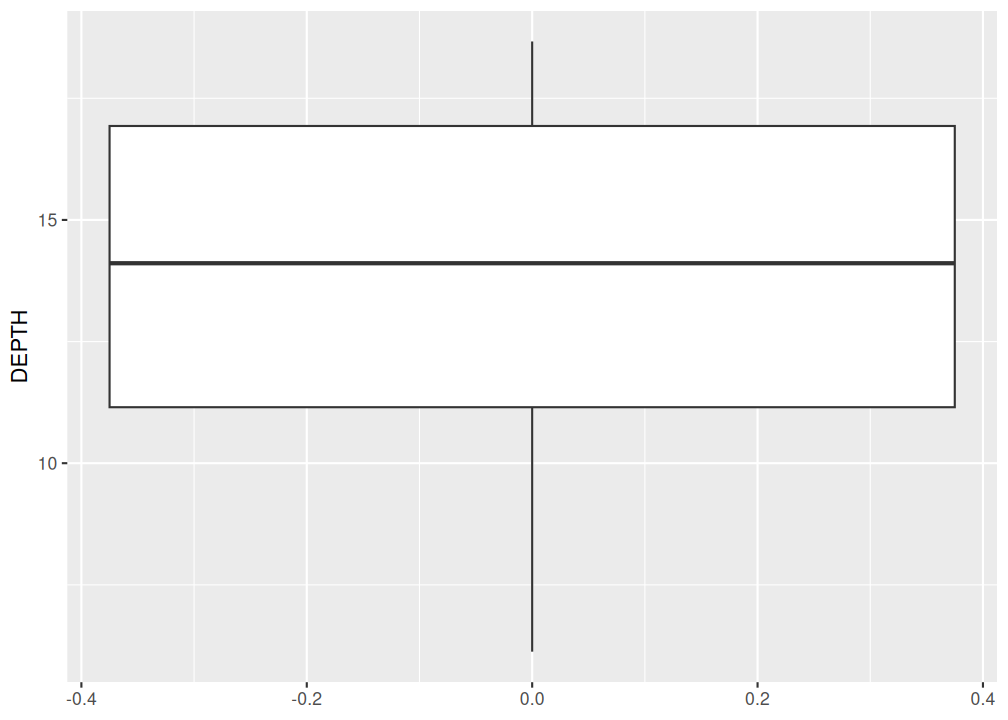

```r
freitas |> ggplot(aes(y = DEPTH)) +
  geom_boxplot()
```

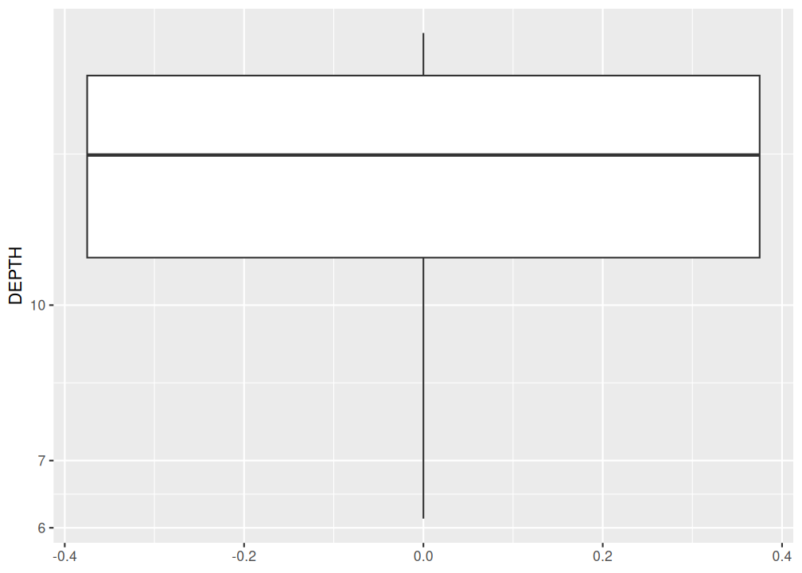

```r
## freitas |> ggplot(aes(y = Dist)) +
##   geom_boxplot()
freitas |> ggplot(aes(y = DEPTH)) +
  geom_boxplot() +
  scale_y_log10()
```

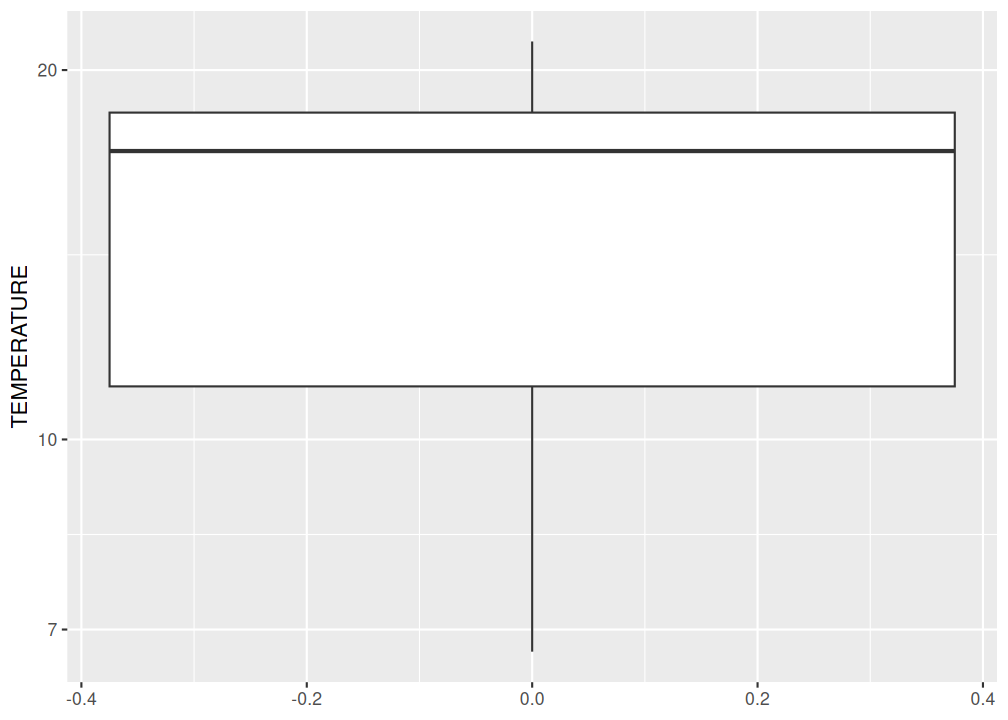

```r
freitas |> ggplot(aes(y = TEMPERATURE)) +
  geom_boxplot() +
  scale_y_log10()
```

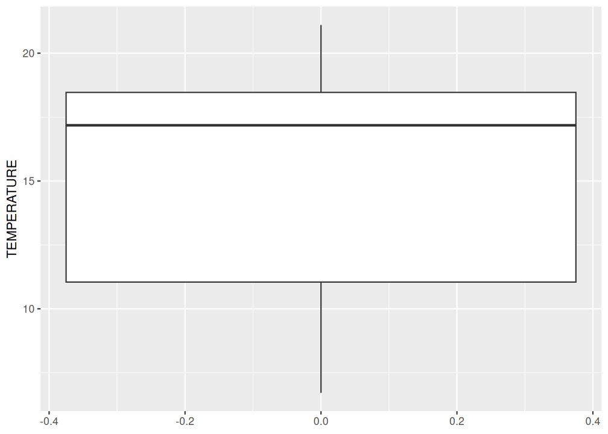

```r
freitas |> ggplot(aes(y = TEMPERATURE)) +
  geom_boxplot()
```

**Scatter plots**

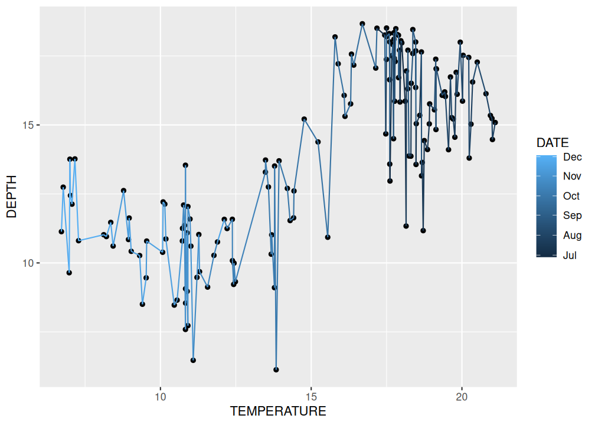

```r
## freitas |> ggplot(aes(y = Dist, x = Day)) +
##   geom_point() +
##   geom_line(aes(group = ID))
freitas |> ggplot(aes(y = DEPTH, x = TEMPERATURE)) +
  geom_point() +
  geom_line(aes(colour = DATE))
```

# 6 Fit the model

**brms**

**Using default priors**

In `brms`, the default priors are designed to be weakly informative. They are chosen to provide moderate regularisation (to help prevent over fitting) and help stabilise the computations.

Unlike `rstanarm`, `brms` models must be compiled before they start sampling. For most models, the compilation of the stan code takes around 45 seconds.

```r
freitas_form <- bf(I(DEPTH) ~ scale(TEMPERATURE),
                family=gaussian(link = 'identity'))
options(width=150)
freitas_form |> get_prior(data = freitas)
```

```
                   prior     class             coef group resp dpar nlpar lb ub       source
                  (flat)         b                                                   default
                  (flat)         b scaleTEMPERATURE                             (vectorized)
 student_t(3, 14.1, 4.3) Intercept                                                   default
    student_t(3, 0, 4.3)     sigma                                         0         default
```

```r
options(width=80)
```

**Defining priors**

The following link provides some guidance about defining priors. [https://github.com/stan-dev/stan/wiki/Prior-Choice-Recommendations]

When defining our own priors, we typically do not want them to be scaled.

If we wanted to define our own priors that were less vague, yet still not likely to bias the outcomes, we could try the following priors (mainly plucked out of thin air):

```r
freitas |>
  summarise(
    Int_mu = median(DEPTH),
    Int_sd = mad(DEPTH),
    b_sd = mad(DEPTH)
  )
```

```
# A tibble: 1 × 3
  Int_mu Int_sd  b_sd
   <dbl>  <dbl> <dbl>
1   14.1   4.32  4.32
```

```r
freitas |>
  mutate(DEPTH = log(DEPTH)) |>
  summarise(
    Int_mu = median(DEPTH),
    Int_sd = mad(DEPTH),
    b_sd = mad(DEPTH)
  )
```

```
# A tibble: 1 × 3
  Int_mu Int_sd  b_sd
   <dbl>  <dbl> <dbl>
1   2.65  0.300 0.300
```

```r
priors <- prior(normal(14, 4.5), class = "Intercept") +
  prior(normal(0, 4.5), class = "b") +
  prior(student_t(3, 0, 4.5), class = "sigma")
freitas_form <- bf(DEPTH ~ scale(TEMPERATURE),
  family = gaussian()
)
## freitas_form <- bf(Dist ~ scale(Day) + scale(TOD),
##                 family=Gamma(link = "log"))
get_prior(freitas_form, data = freitas)
```

```
                   prior     class             coef group resp dpar nlpar lb ub
                  (flat)         b
                  (flat)         b scaleTEMPERATURE
 student_t(3, 14.1, 4.3) Intercept
    student_t(3, 0, 4.3)     sigma                                         0
       source
      default
 (vectorized)
      default
      default
```

```r
## priors <- prior(normal(4.2, 0.2), class = 'Intercept') +
##     prior(normal(0, 0.2), class = 'b') +
##   prior(gamma(0.01, 0.01), class = 'shape')
freitas_brm2 <- brm(freitas_form,
  data = freitas,
  prior = priors,
  sample_prior = "only",
  iter = 5000,
  warmup = 2500,
  chains = 3,
  cores = 3,
  thin = 10,
  refresh = 100,
  seed = 123,
  control = list(adapt_delta = 0.99, max_treedepth = 20),
  backend = "rstan"
)
```

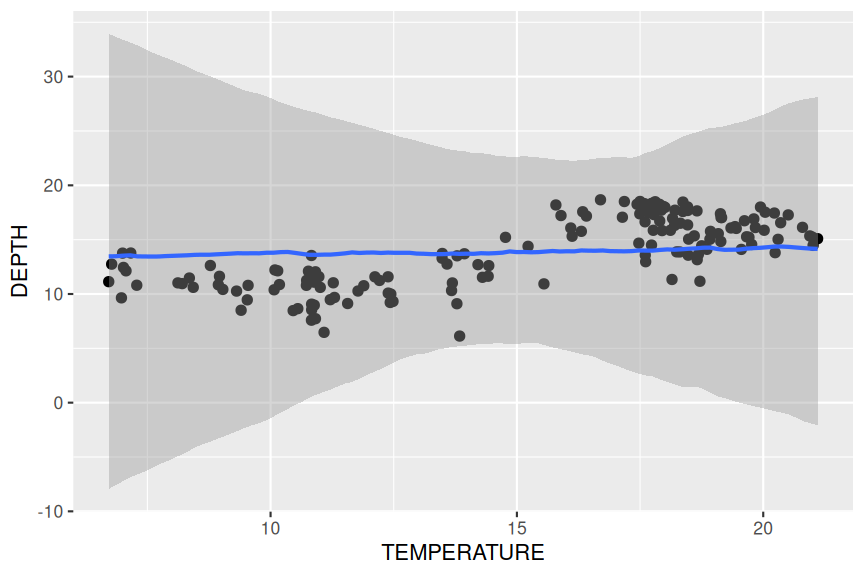

```r
freitas_brm2 |>
  conditional_effects("TEMPERATURE") |>
  plot(points = TRUE)
```

The above seem sufficiently wide whilst at the same time not providing any encouragement for the sampler to wander off into very unsupported areas.

```r
freitas_brm3 <- update(freitas_brm2,
  sample_prior = "yes",
  chains = 3, cores = 3,
  refresh = 100
)
```

```
The desired updates require recompiling the model
```

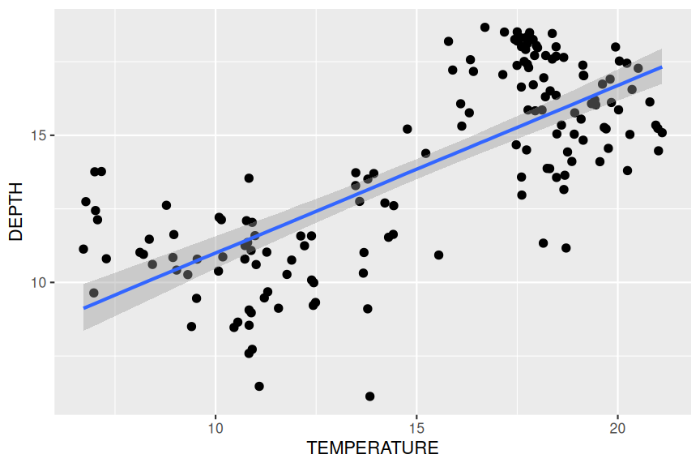

```r
freitas_brm3 |>
  conditional_effects("TEMPERATURE") |>
  plot(points = TRUE)
```

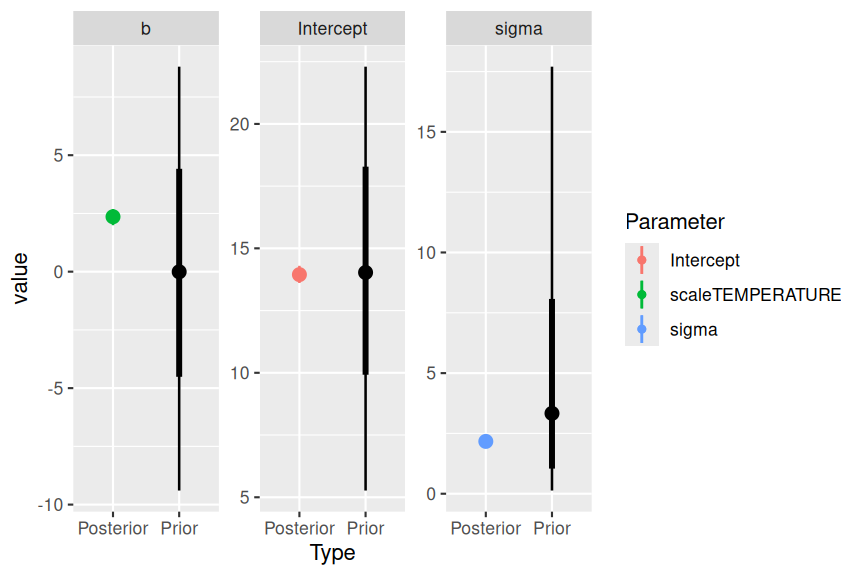

```r
freitas_brm3 |> SUYR_prior_and_posterior()
```

# 7 MCMC sampling diagnostics

**brms**

**stan plots**

The `brms` package offers a range of MCMC diagnostics. Lets start with the MCMC diagnostics.

Of these, we will focus on:

- stan_trace: this plots the estimates of each parameter over the post-warmup length of each MCMC chain. Each chain is plotted in a different colour, with each parameter in its own facet. Ideally, each **trace** should just look like noise without any discernible drift and each of the traces for a specific parameter should look the same (i.e, should not be displaced above or below any other trace for that parameter).

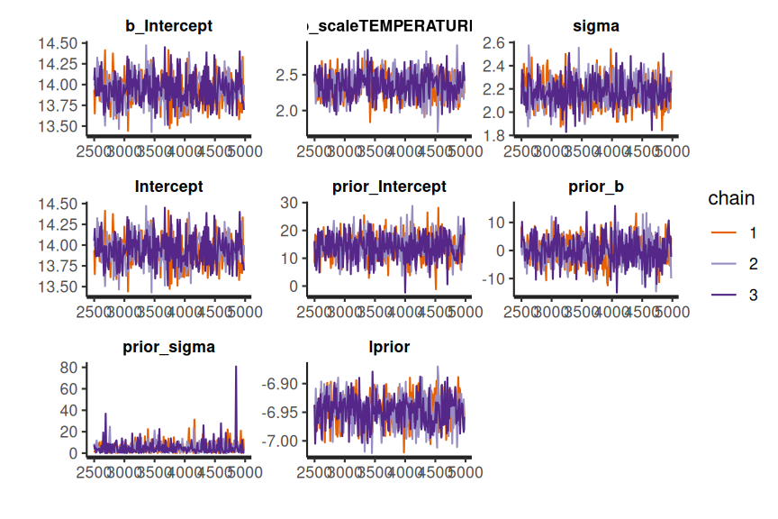

```r
freitas_brm3$fit |> stan_trace()
```

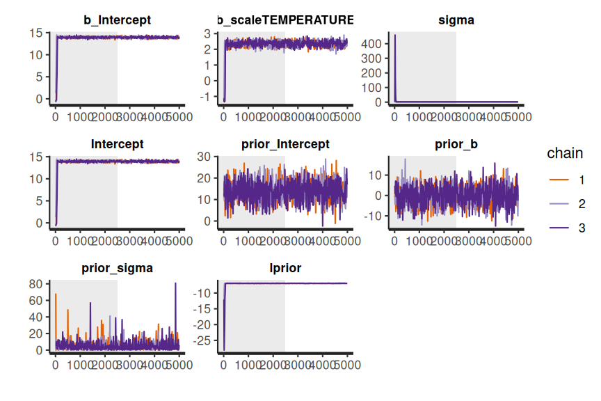

```r
freitas_brm3$fit |> stan_trace(inc_warmup = TRUE)
```

The chains appear well mixed and very similar

- stan_acf (auto-correlation function): plots the auto-correlation between successive MCMC sample lags for each parameter and each chain

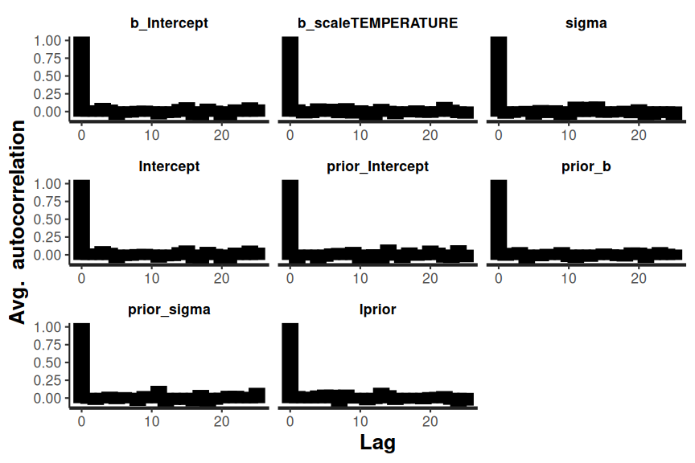

```r
freitas_brm3$fit |> stan_ac()
```

There is no evidence of auto-correlation in the MCMC samples

- stan_rhat: Rhat is a **scale reduction factor** measure of convergence between the chains. The closer the values are to 1, the more the chains have converged. Values greater than 1.05 indicate a lack of convergence. There will be an Rhat value for each parameter estimated.

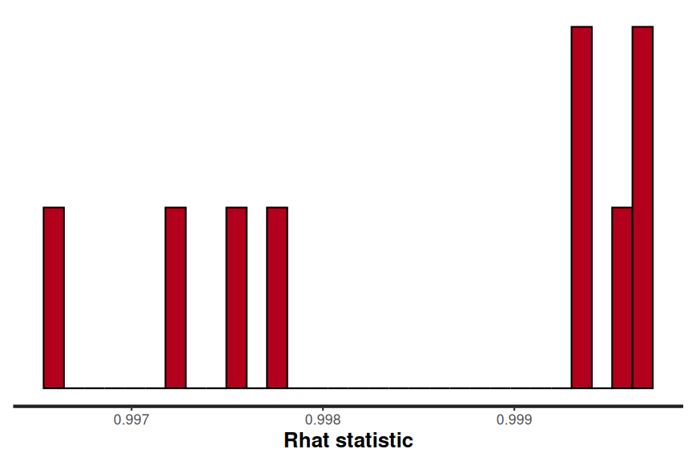

```r
freitas_brm3$fit |> stan_rhat()
```

All Rhat values are below 1.05, suggesting the chains have converged.

- stan_ess (number of effective samples): the ratio of the number of effective samples (those not rejected by the sampler) to the number of samples provides an indication of the effectiveness (and efficiency) of the MCMC sampler. Ratios that are less than 0.5 for a parameter suggest that the sampler spent considerable time in difficult areas of the sampling domain and rejected more than half of the samples (replacing them with the previous effective sample).

  If the ratios are low, tightening the priors may help.

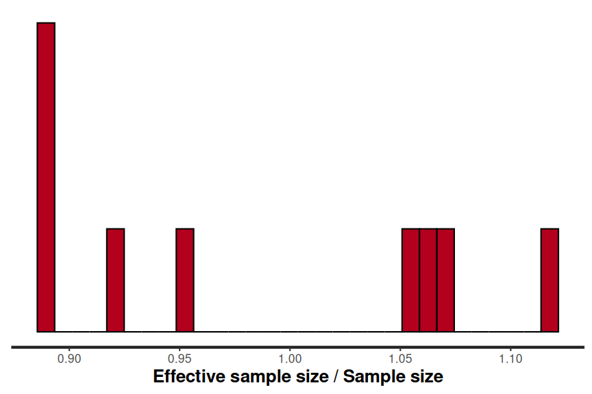

```r
freitas_brm3$fit |> stan_ess()
```

Ratios all very high.

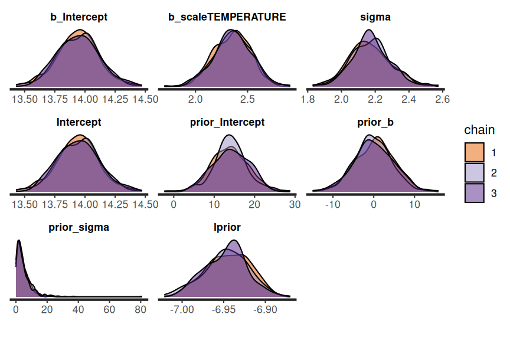

```r
freitas_brm3$fit |> stan_dens(separate_chains = TRUE)
```

# 8 Model validation

**brms**

**pp check**

Post predictive checks provide additional diagnostics about the fit of the model. Specifically, they provide a comparison between predictions drawn from the model and the observed data used to train the model.

```r
available_ppc()
```

```
bayesplot PPC module:
  ppc_bars
  ppc_bars_grouped
  ppc_boxplot
  ppc_dens
  ppc_dens_overlay
  ppc_dens_overlay_grouped
  ppc_dots
  ppc_ecdf_overlay
  ppc_ecdf_overlay_grouped
  ppc_error_binned
  ppc_error_hist
  ppc_error_hist_grouped
  ppc_error_scatter
  ppc_error_scatter_avg
  ppc_error_scatter_avg_grouped
  ppc_error_scatter_avg_vs_x
  ppc_freqpoly
  ppc_freqpoly_grouped
  ppc_hist
  ppc_intervals
  ppc_intervals_grouped
  ppc_km_overlay
  ppc_km_overlay_grouped
  ppc_loo_intervals
  ppc_loo_pit_ecdf
  ppc_loo_pit_overlay
  ppc_loo_pit_qq
  ppc_loo_ribbon
  ppc_pit_ecdf
  ppc_pit_ecdf_grouped
  ppc_ribbon
  ppc_ribbon_grouped
  ppc_rootogram
  ppc_scatter
  ppc_scatter_avg
  ppc_scatter_avg_grouped
  ppc_stat
  ppc_stat_2d
  ppc_stat_freqpoly
  ppc_stat_freqpoly_grouped
  ppc_stat_grouped
  ppc_violin_grouped
```

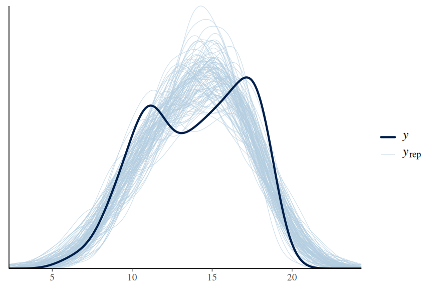

```r
freitas_brm3 |> pp_check(type = "dens_overlay", ndraws = 100)
```

The model draws appear to represent the shape of the observed data reasonably well

```r
# freitas_brm3 |> pp_check(type = 'error_scatter_avg')
```

- intervals: plots the observed data overlayed on top of posterior predictions associated with each level of the predictor. Ideally, the observed data should all fall within the predictive intervals.

```
Using all posterior draws for ppc type 'intervals' by default.
```

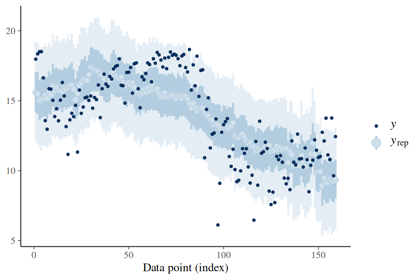

```r
freitas_brm3 |> pp_check(type = "intervals")
```

```r
## freitas_brm3 |> pp_check(group='DENSITY', type='intervals')
```

Whilst the modelled predictions do a reasonable job of representing the observed data, the observed data do appear to be more varied than the model is representing.

The `shinystan` package allows the full suite of MCMC diagnostics and posterior predictive checks to be accessed via a web interface.

```r
# library(shinystan)
# launch_shinystan(freitas_brm3)
```

**DHARMa residuals**

DHARMa residuals provide very useful diagnostics. Unfortunately, we cannot directly use the `simulateResiduals()` function to generate the simulated residuals. However, if we are willing to calculate some of the components yourself, we can still obtain the simulated residuals from the fitted stan model.

We need to supply:

- simulated (predicted) responses associated with each observation.
- observed values
- fitted (predicted) responses (averaged) associated with each observation

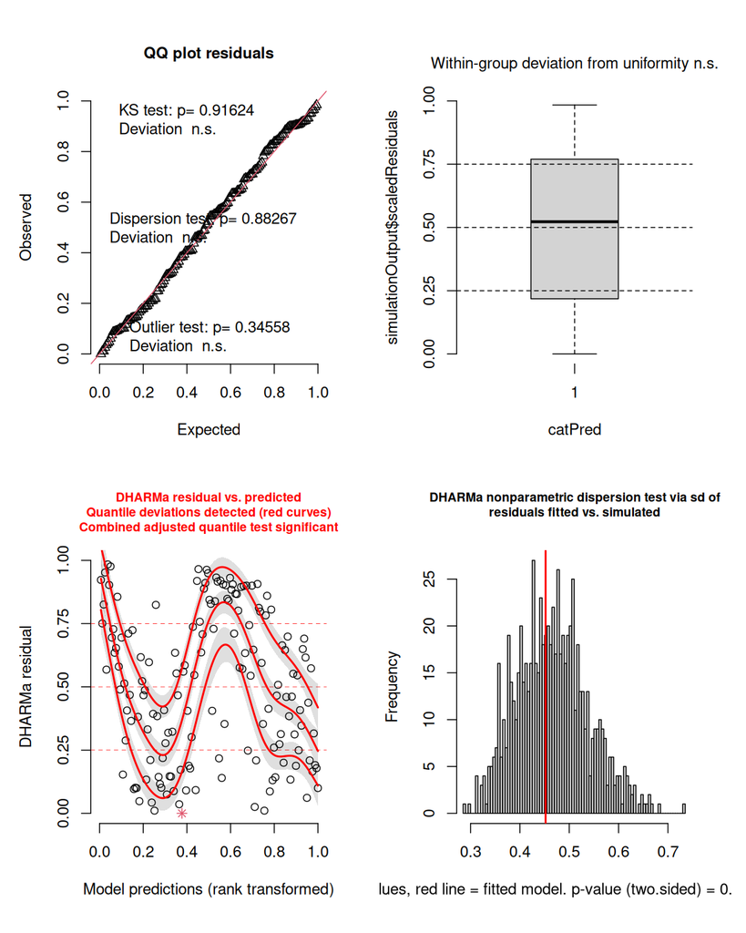

```r
freitas_resids <- make_brms_dharma_res(freitas_brm3, integerResponse = FALSE)
wrap_elements(~ testUniformity(freitas_resids)) +
  wrap_elements(~ plotResiduals(freitas_resids, form = factor(rep(1, nrow(freitas))))) +
  wrap_elements(~ plotResiduals(freitas_resids, quantreg = TRUE)) +
  wrap_elements(~ testDispersion(freitas_resids))
```

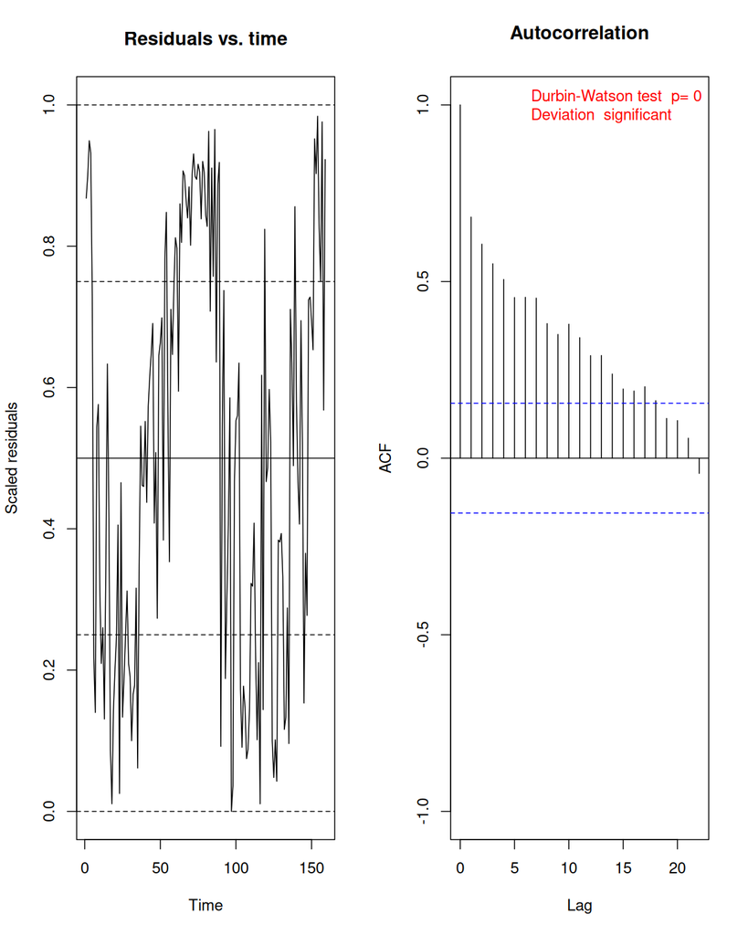

```
    Durbin-Watson test

data:  simulationOutput$scaledResiduals ~ 1
DW = 0.61291, p-value < 2.2e-16
alternative hypothesis: true autocorrelation is not 0
```

```r
freitas_resids |> testTemporalAutocorrelation(time = freitas$DAY)
```

[output not shown]

[output cut: 196 more lines]

[output not shown]

```
Using  as id variables
```

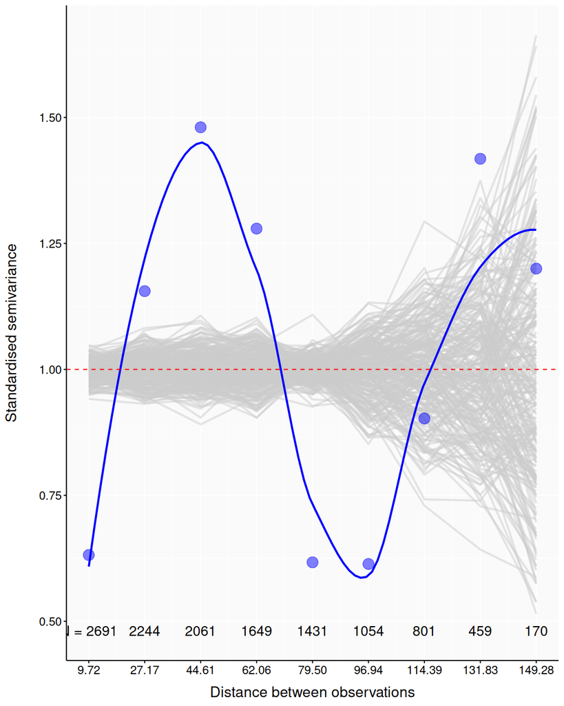

```r
## freitas_resid1 <- freitas_resids |>
##   recalculateResiduals(group = freitas$Day, aggregateBy = mean)
##   ## recalculateResiduals(group = interaction(freitas$Day,  freitas$ID),  aggregateBy = mean)
## freitas_resid1 |> testTemporalAutocorrelation(time=unique(freitas$Day))
autocor_check(freitas, freitas_brm3, variable = "DAY", n.sim = 250)
```

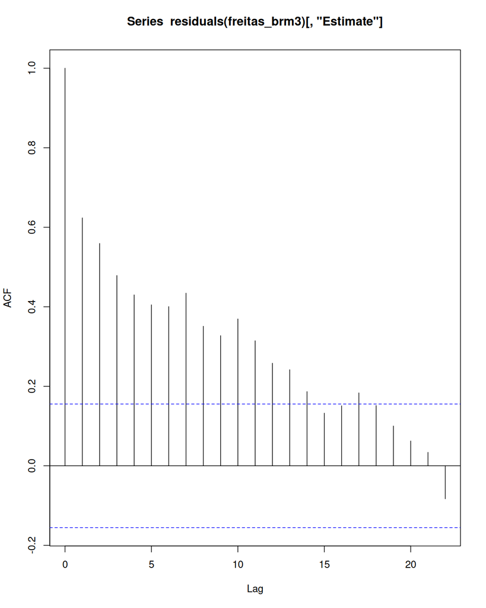

```r
residuals(freitas_brm3)[, "Estimate"] |> acf()
```

**Conclusions:**

# 9 Refit model

```r
freitas_form <- bf(
  DEPTH ~ scale(TEMPERATURE) +
    ar(time = DAY, p = 1, cov = TRUE),
  family = gaussian()
)
get_prior(freitas_form, data = freitas)
```

```
                   prior     class             coef group resp dpar nlpar lb ub
                  (flat)        ar                                        -1  1
                  (flat)         b
                  (flat)         b scaleTEMPERATURE
 student_t(3, 14.1, 4.3) Intercept
    student_t(3, 0, 4.3)     sigma                                         0
       source
      default
      default
 (vectorized)
      default
      default
```

```r
priors <- prior(normal(14, 4.5), class = "Intercept") +
  prior(normal(0, 4.5), class = "b") +
  prior(student_t(3, 0, 4.5), class = "sigma") +
  prior(normal(0, 1), class = "ar", lb = -1, ub = 1)

freitas_brm4 <- brm(freitas_form,
  data = freitas,
  prior = priors,
  sample_prior = "yes",
  iter = 5000,
  warmup = 2500,
  chains = 3,
  cores = 3,
  thin = 10,
  refresh = 1000,
  seed = 123,
  control = list(adapt_delta = 0.99, max_treedepth = 20),
  backend = "rstan"
)
```

[figure not shown]

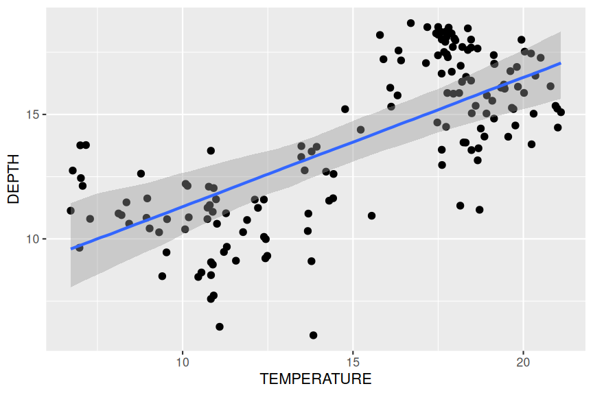

```r
freitas_brm4 |>
  conditional_effects("TEMPERATURE") |>
  plot(points = TRUE) |>
  _[[1]]
```

```r
## freitas_brm4 |> SUYR_prior_and_posterior()
```

## 9.1 stan plots

The `brms` package offers a range of MCMC diagnostics. Lets start with the MCMC diagnostics.

Of these, we will focus on:

- stan_trace: this plots the estimates of each parameter over the post-warmup length of each MCMC chain. Each chain is plotted in a different colour, with each parameter in its own facet. Ideally, each **trace** should just look like noise without any discernible drift and each of the traces for a specific parameter should look the same (i.e, should not be displaced above or below any other trace for that parameter).

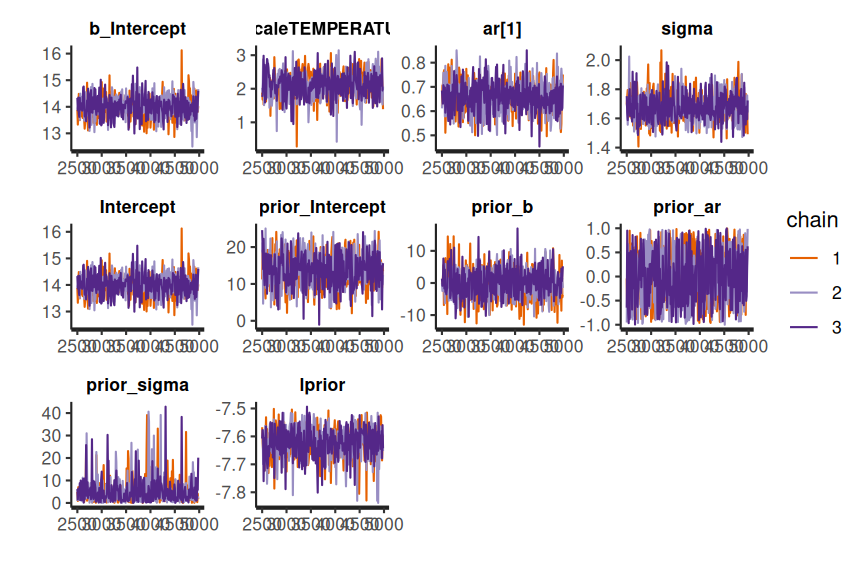

```r
freitas_brm4$fit |> stan_trace()
```

The chains appear well mixed and very similar

- stan_acf (auto-correlation function): plots the auto-correlation between successive MCMC sample lags for each parameter and each chain

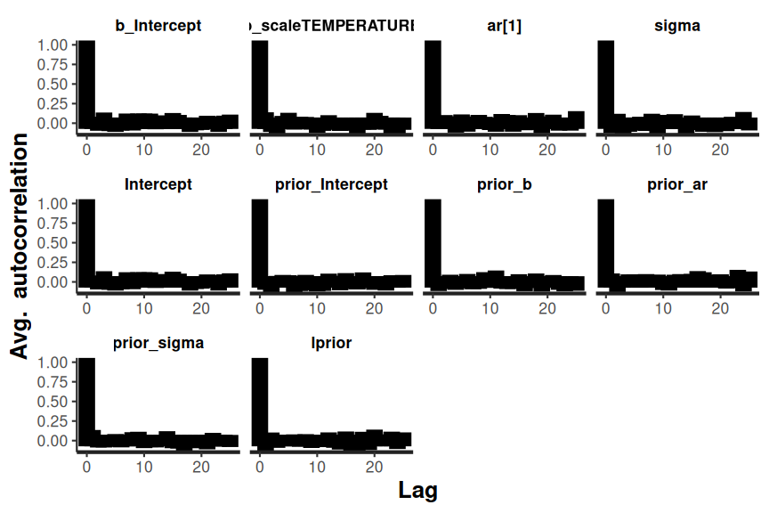

```r
freitas_brm4$fit |> stan_ac()
```

There is no evidence of auto-correlation in the MCMC samples

- stan_rhat: Rhat is a **scale reduction factor** measure of convergence between the chains. The closer the values are to 1, the more the chains have converged. Values greater than 1.05 indicate a lack of convergence. There will be an Rhat value for each parameter estimated.

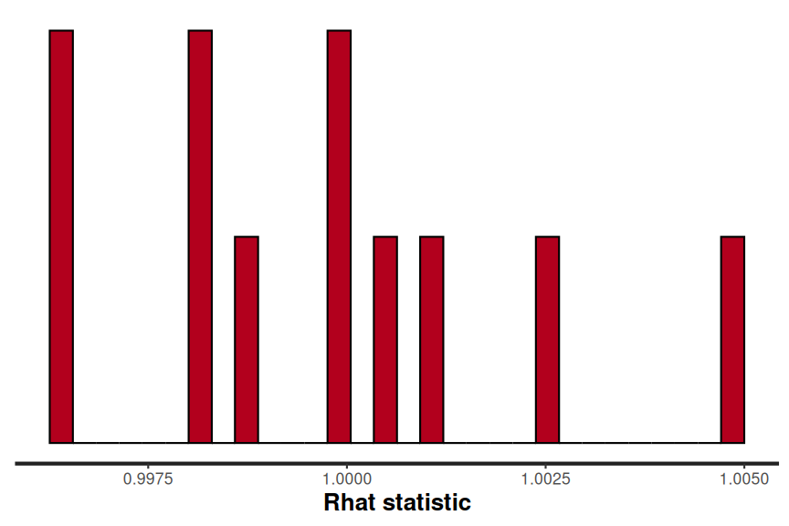

```r
freitas_brm4$fit |> stan_rhat()
```

All Rhat values are below 1.05, suggesting the chains have converged.

- stan_ess (number of effective samples): the ratio of the number of effective samples (those not rejected by the sampler) to the number of samples provides an indication of the effectiveness (and efficiency) of the MCMC sampler. Ratios that are less than 0.5 for a parameter suggest that the sampler spent considerable time in difficult areas of the sampling domain and rejected more than half of the samples (replacing them with the previous effective sample).

  If the ratios are low, tightening the priors may help.

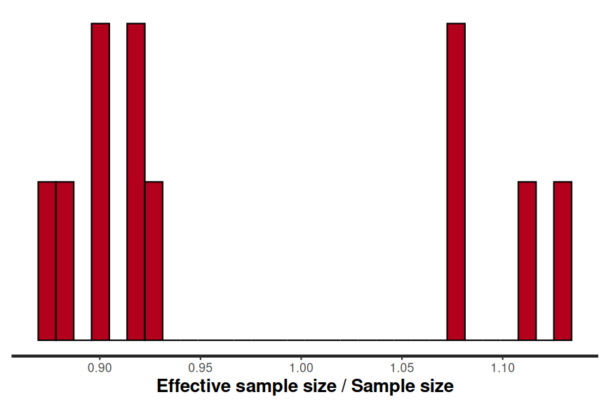

```r
freitas_brm4$fit |> stan_ess()
```

Ratios all very high.

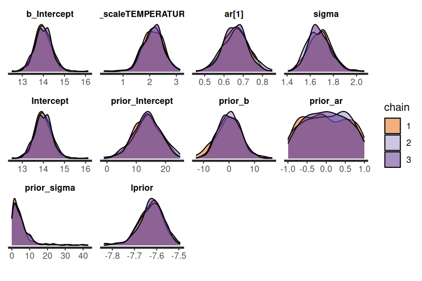

```r
freitas_brm4$fit |> stan_dens(separate_chains = TRUE)
```